# Get co-author comments on draft

Joseph V. Casillas

Last upate: 2022-10-12

```r
library("googledrive")
library("xml2")
library("dplyr")
library("tidyr")
library("ggplot2")
library("forcats")
library("readr")
library("kableExtra")
```

```r
# give gargle permission
drive_auth(email = TRUE)

# Locate file, check ID
drive_find(n_max = 5, type = "document")
```

```
## # A dribble: 5 × 3
##   name                                id                            drive_reso…¹
##   <chr>                               <drv_id>                      <list>
## 1 Draft_RR                            1CFgRo93mRgifpuFOuQE3vNBeMW-… <named list>
## 2 Email - (Almost) ready for comments 1dKVge6TKm4IxXiLenOSOLHXlKfk… <named list>
## 3 READ_ONLY_change_log                13q8VryV5qhw8-nFLvPTV5Hirm1H… <named list>
## 4 READ_ONLY_analysis_workflow         1ETZvJ7RR5RtN771c59bDLn3KIvI… <named list>
## 5 msa_teaming                         16_uUaACz7MkDOliydQPQCYmr4EN… <named list>
## # … with abbreviated variable name ¹drive_resource
```

```r
# Search by id (just checking)
drive_get(id = "1CFgRo93mRgifpuFOuQE3vNBeMW-H7ps9eD--vxH-6CQ")
```

```
## # A dribble: 1 × 3
##   name     id                                           drive_resource
##   <chr>    <drv_id>                                     <list>
## 1 Draft_RR 1CFgRo93mRgifpuFOuQE3vNBeMW-H7ps9eD--vxH-6CQ <named list [35]>
```

```r
# Download to doc folder
drive_download(
  file = "Draft_RR",
  path = "./RR_manuscript/commented_draft/Draft_RR.docx",
  type = "docx",
  overwrite = T
  )
```

```r
# Get word doc and unzip to 'unzipped' folder, will create if doesn't exist
system("unzip -o ./RR_manuscript/commented_draft/Draft_RR.docx -d ./RR_manuscript/commented_draft/unzipped/")
```

```r
# Load xml file
comments_xml <- read_xml("./RR_manuscript/commented_draft/unzipped/word/comments.xml")

# Explore structure
xml_name(comments_xml)
```

```
## [1] "comments"
```

```r
xml_children(comments_xml) %>% head
```

```
## {xml_nodeset (6)}
## [1] <w:comment w:author="Paul Foulkes" w:id="288" w:date="2022-09-27T18:22:15 ...
## [2] <w:comment w:author="Paul Foulkes" w:id="296" w:date="2022-09-27T18:22:44 ...
## [3] <w:comment w:author="Lauren" w:id="357" w:date="2022-10-03T18:47:04Z">\n  ...
## [4] <w:comment w:author="Eleonora Beier" w:id="216" w:date="2022-10-07T19:40: ...
## [5] <w:comment w:author="Hans Westerbeek" w:id="217" w:date="2022-10-11T16:26 ...
## [6] <w:comment w:author="Andrés Buxó Lugo" w:id="156" w:date="2022-10-07T19:4 ...
```

```r
# xml_structure(comments_xml)
# Key structure is: <comment [author, id, date]>

# Get all comments
comments <- xml_find_all(comments_xml, ".//w:comment")
```

```r
# Create df
comments_df <- tibble(
  commenter = trimws(xml_attr(comments, "author")),
  date = trimws(xml_attr(comments, "date")),
  comment = trimws(xml_text(comments)),
  type = "",
  assigned = "",
  solution = "",
  done = "",
  notes = ""
  ) %>%
  arrange(commenter, date) %>%
  write_csv("./data/rr_comments/comment_log.csv")
```

```r
# N commenters
comments_df$commenter %>% unique() %>% length
```

```
## [1] 44
```

```r
# N comments
nrow(comments_df)
```

```
## [1] 435
```

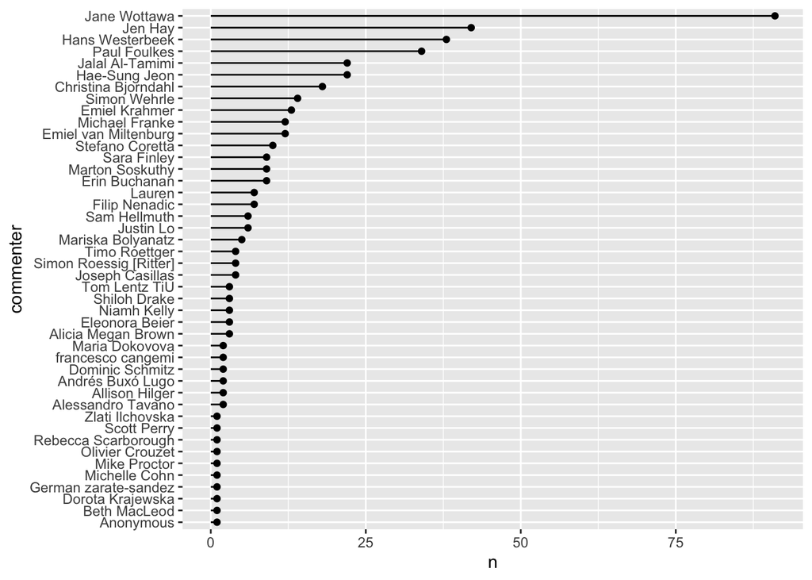

```r
# N comments per commenter
comments_df %>%
  count(commenter) %>%
  mutate(commenter = fct_reorder(commenter, n, min)) %>%
  ggplot() +
  aes(x = n, y = commenter) +
  geom_segment(aes(x = 0, xend = n, yend = commenter)) +
  geom_point()
```

```r
comments_df %>%
  kbl() %>%
  kable_paper("hover", full_width = F) %>%
  scroll_box(height = "500px")
```

commenter

date

comment

type

assigned

solution

done

notes

Alessandro Tavano

2022-09-28T11:20:57Z

Agreed

Alessandro Tavano

2022-09-28T11:27:32Z

very well stated

Alicia Megan Brown

2022-10-09T06:39:02Z

or an indefinite article for ‘vast heterogeneity,’ that would clear up what is (not) being predicted

Alicia Megan Brown

2022-10-09T06:42:53Z

(but yes, would then also require “seem” > “seems”)

Alicia Megan Brown

2022-10-09T06:47:37Z

According to the PDF, the full sentence is “The authors argue that the observed heterogeneity acrossanalysts in Silberzahn et al. (2018) might have been driven by flexibilityin statistically interpreting the research question.”

Allison Hilger

2022-10-03T17:29:11Z

I suggest replacing with the word “treatment”

Allison Hilger

2022-10-03T17:31:21Z

I’m in awe of this figure

Andrés Buxó Lugo

2022-10-07T19:40:00Z

Just marking as a reminder that this link is not included yet.

Andrés Buxó Lugo

2022-10-07T20:25:45Z

One aspect of the project that hasn’t been talked about much is that this was a case where the project was pretty much guaranteed to get published regardless of what our individual analyses found. Unfortunately, this isn’t standard for our fields yet, and so it’s something I can imagine having an impact on the relationship between our priors and our findings. Of course, this is something we should all be avoiding/resisting; I just wanted to point this out as another factor that might increase the chance that we are honest/transparent about analyses in our research.

Anonymous

2022-10-02T08:12:22Z

*Marked as resolved*

Beth MacLeod

2022-10-03T18:19:57Z

Should ‘hope’ be ‘bear’? I’m not sure where ‘hope’ came from.

Christina Bjorndahl

2022-10-11T02:20:54Z

The way this is phrased, one might think that the analyses were distributed independently, but they weren’t, since they were always distributed together with the other analyses from that team. I think this should be made clear since it could have an effect on the ratings.

Christina Bjorndahl

2022-10-11T02:47:15Z

HAHAHA! Well, it looks like we all ignored you and gave you advice anyway. I’ll use the line my mother uses on me and say that it’s given from a place of love… Does that make it better? ;)

Christina Bjorndahl

2022-10-11T02:48:40Z

Yes, this is confusing to me as well: Later on you say that 46 teams submitted their analyses by the established deadline, so does that mean that no one submitted after peer review? In which case, why bring it up here? In general, I’m confused about which analyses and analyst teams were excluded, and how those decisions were arrived at.

Christina Bjorndahl

2022-10-11T02:50:01Z

Echoing the comments here that you need to be explicit about how you went from 46 to 30 analyses; also, were only individual analyses discarded, or all the analyses from entire teams?

Christina Bjorndahl

2022-10-11T02:52:32Z

It’s not totally clear to me how the 170 individual analyses is related to the 104 models. Maybe I’m just missing something, but please clarify.

Christina Bjorndahl

2022-10-11T02:54:50Z

This meaningfulness of this quote is lost on me. What are we supposed to get from it?

Christina Bjorndahl

2022-10-11T02:58:41Z

Outlier treatment needs to be discussed. There were many different approaches to how outliers were assessed and dealt with, and this will have a large effect on the results and the variability. Thinking in particular about creak as the source of outliers for many f0 measurements.

Christina Bjorndahl

2022-10-11T03:00:55Z

Echoing this: If the duration is of vowels, then they need to say it (and in which case, the incomplete neutralization data is irrelevant); if it combines different segment classes, then this is uninterpretable.

Christina Bjorndahl

2022-10-11T03:04:08Z

It seems here that you need to consider experimenter “stake” in the project; since it’s not “our” research, the teams aren’t going to have as strong opinions, which might have altered how teams approached the task. Also, I might address the possibility that researchers didn’t fully understand the experiment design at the point that we had to make that judgement. Remember that you even had to send out a clarifying email re: the AF and ANF conditions, so it seems many people could have had a different opinion if they’d understood the design more fully.

Christina Bjorndahl

2022-10-11T03:31:09Z

Some typos / general small issues with presentation:- missing apostrophe in plural possessives, as in “the authors results” (authors’)- inconsistencies w.r.t. British and American spelling conventions (modelling and modeling)- it’s very difficult to read the figures when rendered in grey scale (as in printing it out); could you add some additional annotations to make this easier?

Christina Bjorndahl

2022-10-11T03:32:29Z

Here it’s clearly stated that the ANF and AF conditions are just fillers. This was not conveyed clearly to the analysis teams, and conveying it might have cut down some of the variability in analyses and effect sizes found by discouraging groups from trying to include measurements from those filler conditions. This could merit a paragraph in the discussion section (though not here)

Christina Bjorndahl

2022-10-11T03:33:12Z

It’s not clear whether all 46 submitted teams’ work were reviewed by other teams, or only the 30 included in quantitative analyses.

Christina Bjorndahl

2022-10-11T03:34:42Z

It would be clearer to add an example to the measure of uniqueness definition. This may be common in Many Analyses projects, but the paper will, I think, have broad interest to linguists, and so would be helpful. From N. Warner: I would ask for an actual hypothetical example from this project. Something like “For example, if one team used LMEs to analyze two dependent variables (adjective duration and peak f0 during adjective), both including the same three independent variables, and an additional … test of … on a third dependent variable (…), the pair of analyses consisting of the two LMEs with different dependent variables would have X of … and Y of …, leading to SDI of …” The could maybe go further with “An analysis team that submitted 5 different analyses of different dependent variables, with each of them using a different statistical method and several different predictor variables, might have an SDI of …, while one submitting just two analyses, which differ only in dependent variable, would have one of ….”

Christina Bjorndahl

2022-10-11T03:36:03Z

This really sounds like the descriptive statistics given describe the individual analysts, rather than the team averages. It did mention team averages above, but here where it says that “analysts had” a range of years post PhD from -3.8 to 12.4, that really sounds like all groups containing someone with more seniority than that got excluded.

Christina Bjorndahl

2022-10-11T03:37:36Z

N. Warner: I think this method of “shrinkage” of the effect sizes really needs to be explained more thoroughly, ideally with an example. Is this what was explained on p. 19 (of the pdf)? I can’t even tell if that’s where the explanation of it was, and it’s crucial to understand this, since it reduced the percentage of analyses with significant/non-zero effects from about 22% to 16%. If I’m just being dense here and it’s explained, then this needs an “as explained in … above.”

Christina Bjorndahl

2022-10-11T03:38:19Z

N. Warner: I think this is an overly positive interpretation. Rating an analysis as publishable with major revision leaves a lot of leeway for pretty bad analyses, since major revision can include changing every aspect that was used in these analyses, such as dependent variables, measurement time period, statistical model, etc.

Christina Bjorndahl

2022-10-11T03:39:56Z

This would be an ideal place to elaborate discussion of whether some teams lacked expertise in phonetics and joined the project thinking they would be doing only the statistical portion. One of the analyses we reviewed explicitly stated that they lacked phonetics training and weren’t going to learn now, so they used what they could immediately and obviously extract from the files without any phonetic methods. But there probably were some other teams like that.

Christina Bjorndahl

2022-10-11T03:41:27Z

This section would also be an excellent place to add a paragraph about the role of journal reviewers and editors in catching poor choices of dependent variable, measurement method, time span over which measured, etc. These are very typical items to bring up during the review process, regardless of which statistical method is preferred, and many of the analyses in the current project would not have gotten through review at a phonetics journal. I can’t help but wonder if there were a second round (namely, if we treated all analyses as a “revise and resubmit”), would the results start to converge?

Dominic Schmitz

2022-09-28T07:32:39Z

this should be either lowercase (if English) or “Banane” (if German)

Dominic Schmitz

2022-09-28T07:34:19Z

times

Dorota Krajewska

2022-10-10T18:34:44Z

delete “)”?

Eleonora Beier

2022-10-07T19:34:04Z

I think somewhere in this section or elsewhere, it should also be mentioned that each team chose how to force-align the textgrids to the correct word and phoneme boundaries. We saw lots of variability for how this step was taken

Eleonora Beier

2022-10-07T19:40:28Z

does this mean significant?

Eleonora Beier

2022-10-07T19:50:53Z

I agree with this, and in addition it would be useful to know which of these analyses were performed on which parts of the sentence. For example, it might be that there were more models finding significant effects for the adjective as opposed to the noun regions? Perhaps there could be a more detailed version of this figure (i.e. split by acoustic variable analyzed and region analyzed) in the supplementary materials

Emiel Krahmer

2022-10-10T18:06:49Z

I agree with (other) Emiel! Perhaps write something like: ““researchers may find themselves exploring many possible analytic pipelines, but only reporting a selected few”

Emiel Krahmer

2022-10-10T18:07:43Z

Yes, I agree – I am assuming the topic whether soccer referees are more likely to give red cards to dark-skin-toned players

Emiel Krahmer

2022-10-10T18:10:13Z

Would be good to reiterate that this is averaged over teams (it would be interesting to also see figure for individual researchers – was there much agreement within analysis teams? my guess, based on N=1, would be “no”)

Emiel Krahmer

2022-10-10T18:11:21Z

I think it is important to add that roughly half of these 27 find a significant positive and the other half a significant negative effect. This, to me, reinforces the conclusion that “our best guess is that speakers might not encode typicality in the acoustic signal”

Emiel Krahmer

2022-10-10T18:12:54Z

Here too, I feel that this is primarily consistent with there not being an effect - might be worth pointing this out

Emiel Krahmer

2022-10-10T18:14:22Z

I agree. Additionally, I am not sure why this sentence is what is concluded from the previous one… More unique models are also more marked/less in line with the consensus.

Emiel Krahmer

2022-10-10T18:15:52Z

indeed, not a lot of variation – to what extent do such small differences fall within the margin of measurement error? Might be interesting to say something about this.

Emiel Krahmer

2022-10-10T18:17:35Z

I am not sure whether this is a bias per se. Researchers can have a theoretical reason to expect an effect of, say, pitch, but that does not necessarily mean that they are biased, right?

Emiel Krahmer

2022-10-10T18:19:53Z

Couldn’t also argue that multiple approaches allow for more “severe testing” (in the sense proposed by Deborah Mayo)? That is potentially a good thing

Emiel Krahmer

2022-10-10T18:21:30Z

I wonder whether the data here suggest that selective reporting is an issue (after all: many teams provide multiple models with multiple non-significant findinds). The point is true in general, of course. Come to think of it, it might be interesting to draw a p-curve for this study!

Emiel Krahmer

2022-10-10T18:24:35Z

I agree in general, but playing the devil’s advocate: many of the variables researchers can choose will be related (this is clear for min, max, range, SD of F0, but also between, say, pitch and duration) – so the choice problem (which variables to measure) is perhaps less dramatic than the manuscript currently suggests

Emiel Krahmer

2022-10-10T18:32:56Z

This is a general comment: the paper sometimes reads as if the authors want to highlight the “wide variability” between the teams (and there is indeed a lot of variability). At the same, I also see a lot of agreement between analysis teams, and while reading sometimes felt that a slightly more nuanced discussion of this would be in order.

Emiel Krahmer

2022-10-10T18:33:45Z

BTW: I do want to stress that I really appreciate all the hard work the lead authors put in, and greatly enjoyed reading the manuscript!

Emiel van Miltenburg

2022-10-10T09:41:43Z

I always thought that operationalization applies to constructs (e.g. “we operationalise stress in terms of an increase in loudness”), not to the signal you use.

Emiel van Miltenburg

2022-10-10T09:43:27Z

I’m not sure everyone would agree with this. (One reading of this sentence would amount to admitting that we often carry our questionable research practices.)

Emiel van Miltenburg

2022-10-10T09:44:43Z

Missing reference.

Emiel van Miltenburg

2022-10-10T09:45:04Z

Same here.

Emiel van Miltenburg

2022-10-10T09:45:56Z

Also hard to understand how this works in practice. How does a research question impact heterogeneity? (E.g. by being too general and allowing for multiple interpretations?)

Emiel van Miltenburg

2022-10-10T09:48:38Z

In the PDF version all text in math mode reads as if there’s a LaTeX mistake: math mode should be escaped to render the text in a nicer way.

Emiel van Miltenburg

2022-10-10T09:51:35Z

Would be nice to say a bit more about the limitations of your analysis if it cannot account for analyses from 16 teams, and to indicate where (if applicable) data from these teams *was* taken into account

Emiel van Miltenburg

2022-10-10T09:52:35Z

During our reviews we found that there was also variation in the extent to which analysts used the entire dataset. Some only used a subset that they considered relevant. This variation is not reported.

Emiel van Miltenburg

2022-10-10T09:53:32Z

This echoes the earlier comment by Paul Foulkes. I agree with both comments.

Emiel van Miltenburg

2022-10-10T10:03:44Z

The paper notes that the generalisability of our findings is limited, but it is not made precise what the authors mean by generalisability. The paragraph remains general/vague about this. Generalisable in what sense? What can/cannot others learn from our study? Which parts of the findings *are* generalisable? It would be really nice to have a more detailed discussion about what it means for a study like this to be generalizable, and what it would take to carry out a similar study for more qualitative analyses. You could also refer to Haven & Van Grootel (https://www.tandfonline.com/doi/pdf/10.1080/08989621.2019.1580147) in this context. Their study also provides a framework for thinking about dimensions of variation (although they don’t present it as such; for them it’s a means to provide transparency and ensure rigour).General remark: At times the paper feels like it wants to stay at a very abstract level, to ensure maximal generalizability, but at the same time this paragraph says the implications don’t really extend beyond the speech sciences.

Emiel van Miltenburg

2022-10-10T10:15:29Z

We have a speech scientist on our team, but I wouldn’t dare calling myself a speech scientist. Hard to find an alternative though. Perhaps “language scientists” or “linguists” would be better? (the former term may be more inclusive of psychologists)

Emiel van Miltenburg

2022-10-10T10:28:47Z

Great discussion also in this thread! I’d like to second Jen’s concerns, and would also like to point to the limitations section (Caveats) above where the same issue appears. It may be good to reflect a bit more on what generalisability even means for this type of study.Random thought:To some extent it’s there already, but maybe we can make this a bit more concrete: if your research question/problem has properties A/B/C, then based on our observations we would recommend that you do X. Like a flow chart or table with advice.

Erin Buchanan

2022-10-11T14:20:31Z

+1, this is slightly awkward as worded

Erin Buchanan

2022-10-11T14:32:03Z

- 1

Erin Buchanan

2022-10-11T14:33:58Z

I’m also commenting here on what 170 means, feels like you need a noun here 170 X from 30 teams

Erin Buchanan

2022-10-11T14:36:22Z

Good question … since I believe unless I lost my mind during the intake, I would have been over this number

Erin Buchanan

2022-10-11T14:46:05Z

Same - we specifically talked multiple times … there should be “one” number (i.e., effect size) so we shouldn’t run a bunch of stuff

Erin Buchanan

2022-10-11T14:48:58Z

+1 to me this feels like the most important section, but I can’t totally grasp what it is saying - I know Timo doesn’t love mixing results + discussion but maybe a simple interpretation right here to solidify what to expect in the discussion

Erin Buchanan

2022-10-11T14:53:19Z

yipes - basically, this type of research often promotes data exploration until you see it?

Erin Buchanan

2022-10-11T14:54:33Z

+1 we spent a lot of time discussing how it was vague :)

Erin Buchanan

2022-10-11T14:55:31Z

great job guys! Some serious work put in here.

Filip Nenadic

2022-10-03T06:06:02Z

Are we certain that all possible combinations are also plausible and can be implemented in practice?

Filip Nenadic

2022-10-03T06:18:08Z

I second this; even if “to bias an estimate” is a standard way of saying this, I would rephrase it.

Filip Nenadic

2022-10-03T06:42:01Z

I think we may want to give some credit to or at least mention conceptual replication here. Of course, a conceptual replication that does not yield the same results as the original study might do so for a number of reasons (some of which methodological), but at least it draws attention to a possible bias in the original study design and analysis.

Filip Nenadic

2022-10-03T06:48:57Z

An uninformed reader (like perhaps myself, since I’m raising this issue) may here not be able to distinguish this approach from what we previously discussed in the following: “Based on our personal experience with research in the field, it is common practice to test as many different types of models, using as many different types of measurements, to answer one research question. When operating within the frequentist inferential framework, testing the same hypothesis with different dependent variables is known to increase the false-positive (Type-I error) rate.” Perhaps it would be good to somehow draw a clearer distinction between the two approaches.

Filip Nenadic

2022-10-03T07:14:08Z

I may be missing the mark here, but I think we should also mention that, along one dimension, this work is a case study (not necessarily in those words). What I mean is – the amount of observed variability in data preprocessing, analysis options and especially the results might depend on the characteristics of the study design and the dataset. In this work we all “tested” a single dataset. We may claim that this particular dataset is standard in the field or representative of speech science studies, but it is still one dataset. I also realize that measures of results variability are discussed, but we do make note that these pass certain thresholds important in the field. If we imagine – so hypothetically – that the dataset we used was somehow small or bad or imbalanced, one could imagine (again, hypothetically) that with a larger dataset and a stronger actual effect present within, the observed estimate variation could be similar (or smaller), and that we would conclude that no such thresholds important in the field have been touched despite sizeable differences in the decision trees (in fact, I believe this is one of the things the field currently aims at: showing that a qualitatively described effect exists even under duress of perturbations in methodologies and analyses). Simply put, the number of pipelines and the number of some qualitative biases in interpretation could be expected to differ from study to study and dataset to dataset and I cannot help but wonder just how much variability there is and how this analysis section might have looked had we used a different study. I apologize for the poorly structured comment and if this has been addressed somewhere and I somehow missed it.

Filip Nenadic

2022-10-03T07:25:11Z

I mentioned this above – but this is perhaps the case only if the effect itself is small or inconsistent or dependent on some other factor the field does not yet account for. Such effects (hopefully) get better described or purged from the literature as the field advances. Although I do agree with this claim, maybe we wouldn’t be able to make this claim based on empirical evidence had we used a different dataset.Or in other words – how frequently are acceptable approaches expected to lead to inconclusive results?I am not sure what could be done about this in the manuscript if anything even should.

Filip Nenadic

2022-10-03T07:30:00Z

I believe it should be mentioned that the researchers were forced choose one analysis in a field where it is standard practice to look at a few, say, dependent variables at the same time (not necessarily in these words). I am not trying to say that the variability isn’t or wouldn’t still be large, but I think we could have seen some substantial convergence or more overlap if the authors were asked to, e.g., list top three or four analyses they would do.

francesco cangemi

2022-10-04T17:53:58Z

TLWR: Given the results of the team analyses and the premises of the metastudy, I also fear that other readers might be confused at (or irked by) the strong wording of “vastly different answers”, and I suggest to tone it down.Hi all. Apologies for the textwall, but I also have a problem with this sentence, and for two reasons: (a) results and (b) premises. (a)Results. We can’t really say that the answers to the research question are vastly different. We mostly agree on the answer: there is no effect. Where we diverged, is in the paths we took to get to this outcome. Granted, there are a few analyses where some of these paths led to a “positive” result, but even then, there’s at least one case (i.e. periogram analysis) where the positive results were interpreted as linguistically meaningless. And note that in this specific case the pitfall of “yay, significant!” was not avoided thanks to virtuously cautious inferences in the quantitative analysis. It was rather avoided thanks to a close, hard look at the plausibility (from the communicative and linguistic point of view) of the research question and of the dataset collected to answer it. Which brings me to:(b)Premises. At a more fundamental level, I am not sure I find it unhealthy that different analysts opted for different operationalisations of the research question. This is only surprising or problematic if we presuppose a modular approach to research, with neatly separated boxes for Delimitation of research question > Design of study > Collection of data set > Extraction of metrics > Quantitative analyses. In my view, for example, Design interacts with both Delimitation and Extraction. Modularity here (as everywhere else?) is only a wishful oversimplification of how research into human behaviour should work.

francesco cangemi

2022-10-04T17:54:07Z

In other words, I really agree with your mention of Dubin’s (1970, or 1969) on derivation chains – our research should develop the link between conceptual constructs and quantitative system, e.g. the link between how we define typicality and where/how we could expect it to be encoded phonetically. In my view, it is this link that saves us from being overconfident in claiming positive results (and not this or that one statistical technique). However, this link is also severed in this study, and by design. We are handed a dataset harvested according to certain assumptions, and we are expected to make sense of it. In this situation, we cannot own the derivation chain. And still, despite all this, most of us converged on saying that “this dataset offers no robust evidence for a phonetic encoding of typicality”. That’s actually quite impressive!

German zarate-sandez

2022-10-01T22:10:19Z

… f0 minimum or maximum. (ie., eliminate second “value”. Otherwise, it reads “measure the value … of … the… value”)

Hae-Sung Jeon

2022-10-01T09:37:12Z

question mark?

Hae-Sung Jeon

2022-10-01T09:46:28Z

I agree. Or just remove ‘suprasegmental’.

Hae-Sung Jeon

2022-10-01T09:54:08Z

Maybe add some references of influential/wide-cited studies where this method was used. I wouldn’t think letting participants interact with an experimenter as a typical methodological choice in the field.

Hae-Sung Jeon

2022-10-01T12:16:11Z

👍

Hae-Sung Jeon

2022-10-01T12:33:47Z

My interpretation is that some used predictors which were not commonly used in other analyses and therefore ‘unique’. (I wonder how those ‘unique’ (non-conformist) ones did at the review stage.)

Hae-Sung Jeon

2022-10-01T12:39:54Z

I wholeheartedly agree. The researcher degrees of freedom given the open nature of the research question and the rather unusual design of the dataset here is a positive thing. It’s a different issue from the replication ‘crisis’ that the conclusions are inconsistent despite the use of similar research paradigm across studies.

Hae-Sung Jeon

2022-10-01T13:03:40Z

I agree with Jen’s comment above. These findings are valid, probably showing that that speakers didn’t do much with f0 for the typicality contrast but formant results were different because different words were used in different typicality conditions. Some teams looked at the former, other teams looked at the latter, so now we have a pretty good picture about that’s going on in the data.

Hae-Sung Jeon

2022-10-01T13:24:14Z

The statements from here for the rest of this paragraph sound too general too me, and probably they should be more concretely linked to the present results. Is there evidence that, for instance, non-frequentiest approaches in the present study yielded more consistent results than frequenties approaches?

Hae-Sung Jeon

2022-10-01T13:31:57Z

I agree. I understand that the point of this particular paper is about methods, but there’s a lot of useful information collected which is in fact highly relevant to acoustic phonetics. It would be cool to break down the results further to look at the variability within each linguistic domain and also within each acoustic parameter. :)

Hae-Sung Jeon

2022-10-01T13:32:59Z

👍

Hae-Sung Jeon

2022-10-01T13:37:17Z

Eh…maybe slightly expand this, or cite references (e.g. Ladd 2008 and therein) to address the phonological, acoustical, and cross-language complexity of word stress? .. And I disagree that this is ‘underspecification’.Are there any other examples of ‘underspecification’ in speech literature?there any good examples to share, which are just rightly specified?

Hae-Sung Jeon

2022-10-01T13:38:38Z

I agree. And looking forward, as a research community, we can collectively come up with important research questions which require large scale studies and replications.

Hae-Sung Jeon

2022-10-01T13:39:27Z

Agreed; the variability here was a natural consequence given the broad research question, the multidimensional nature of speech, and the unusual data design. I don’t find the outcomes as concerning as it’s described here. :-p

Hae-Sung Jeon

2022-10-01T13:42:53Z

How is this relevant to the present study?

Hae-Sung Jeon

2022-10-01T13:44:01Z

The same here. What’s exactly the minimum variability, and what is concerning?

Hae-Sung Jeon

2022-10-01T14:00:31Z

Congratulations on this massive achievement! I really enjoyed reading the paper – good food for thought. If I were a reviewer, I would have said that the discussion and conclusions seemed to be only loosely linked to the analysis. The meta-analysis seems to be too ‘meta’ to resonate with phonetics folks ;) As Jan says above, I’d have liked to see a more fine-grained analysis in the ideal world.

Hae-Sung Jeon

2022-10-03T22:26:51Z

*Marked as resolved*

Hae-Sung Jeon

2022-10-03T22:27:32Z

*Marked as resolved*

Hae-Sung Jeon

2022-10-03T22:29:44Z

*Re-opened*

Hae-Sung Jeon

2022-10-03T22:29:52Z

*Re-opened*

Hae-Sung Jeon

2022-10-03T22:44:20Z

I’d frame the narrative more positively. There are different levels of variability; the between-team variability that we’ve seen here is healthy. The kind varibilty that I’d be concerned is, something like, different people use different settings or measuring units for f0 or formants presenting different values all claiming that they use Praat, or the same analysis receiving wildy varying review scores. The latter kind of variability has not been analysed in the present paper but the data are available for exploration.

Hae-Sung Jeon

2022-10-04T07:42:18Z

Probably you should highlight in the discussion section that you are interpreting the present results in the context of the current frequentist landscape. Had there been more researcher variability since the early 20th century and not everyone followed the frequentist approach, we would have been better off now..

Hans Westerbeek

2022-10-11T16:06:04Z

Agreed

Hans Westerbeek

2022-10-11T16:07:15Z

This title makes clear that making an estimation (i.e. providing descriptive statistics) is the main goal of the article. The actual goals as described further on in the introduction however are a little bit less clear to me.

Hans Westerbeek

2022-10-11T16:09:14Z

I find it a little hard to follow the goals, especially goal ii. If previous studies have established that there is vast variation between analysts and analyses (with differing consequences), what is the reason to replicate this in a domain that might elicit even more variation? I feel that this is highly interesting, but I am afraid that the argument as to why this is the case is missing at the moment.

Hans Westerbeek

2022-10-11T16:09:56Z

re: my previous comment. I think that this conclusion can not yet be drawn at this moment. Why would this study yield a more realistic estimate than previous work?

Hans Westerbeek

2022-10-11T16:10:28Z

I found this hard to follow. Consider rephrasing?

Hans Westerbeek

2022-10-11T16:12:35Z

Emphasize that these are the *thoeretical* alternative pipelines. In practice, research fields have conventional, often-used measures, for example. This is also reflected in the observation that many of our analyst teams used f0.

Hans Westerbeek

2022-10-11T16:13:29Z

Yes

Hans Westerbeek

2022-10-11T16:15:36Z

I think that the Westerbeek et al. reference fits here better than where it is now. Additionally I think that there are better references available to substantiate the claim made above (“peakers use referring expressions that are more specific than strictly necessary for the unambiguous identification of the intended referent”).Anyway, please keep the Westerbeek et al. reference in the paper :-)

Hans Westerbeek

2022-10-11T16:16:50Z

I feel that in this paragraph a lot of prior knowledge on linguistics and phonetics is assumed. This contrasts with the earlier sections on phonetics, which seem to assume that the topic is relatively new for the readership.I think this latter perspective is the most useful.

Hans Westerbeek

2022-10-11T16:18:16Z

Would it be relevant to emphasize that this was not spontaneous/natural speech? Some of the referred work deliberately did not employ reading aloud as a data gathering method.

Hans Westerbeek

2022-10-11T16:20:08Z

Agreed. Please explain more about this process. How were these 170 analysis deemed eligible?

Hans Westerbeek

2022-10-11T16:20:38Z

Agreed. Please consider more informative descriptive statistics, such as range and mode.

Hans Westerbeek

2022-10-11T16:21:01Z

Agreed. My thought was to report range and mode.

Hans Westerbeek

2022-10-11T16:21:52Z

Please change the word ‘younger’ into ‘less experienced’ or something like that. We are not describing the analysts’ age here.In the results section you use the (better) term ‘seniority’.

Hans Westerbeek

2022-10-11T16:22:32Z

Maybe these sentences can be left out altogether.

Hans Westerbeek

2022-10-11T16:23:28Z

Please refer to this table in the beginning of the paragraph instead of at the end.

Hans Westerbeek

2022-10-11T16:24:40Z

Agreed. Please rephrase. Also consider adding decimals and other precision to this number (range? sd? mode?)

Hans Westerbeek

2022-10-11T16:25:22Z

Agreed.

Hans Westerbeek

2022-10-11T16:26:27Z

Please clarify whether you mean statistically significant (at p<.05?), and whether these effects pointed in same or opposite directions.

Hans Westerbeek

2022-10-11T16:30:12Z

These analyses are obviously, and for good reasons, aimed at uncovering variability and inconsistencies between analysis and analysts. However, one might take a critical stance and claim that there is too little attention for consistencies in the analyses and in the conclusions that different analysts have drawn. As an effect, these results seem to underappreciate this agreement (and also do not fully reflect some of the literature reviewed in the introduction).

Hans Westerbeek

2022-10-11T16:30:59Z

Why the ±? It is just a rounded 0.021, right?

Hans Westerbeek

2022-10-11T16:34:27Z

What is ‘compellingly’? Is it anything different from ‘significantly’ in the statistical sense?

Hans Westerbeek

2022-10-11T16:40:05Z

Agreed.

Hans Westerbeek

2022-10-11T16:42:35Z

Agreed. This may well be an artefact of the research question the teams worked on. Note that this research question covered any possible acoustic measure, as it asked about *any* acoustic modification of speech as a result oftypicality.

Hans Westerbeek

2022-10-11T16:44:05Z

Now that you mention it - I assumed I need to read the forest plot like a box plot, but I am not sure.

Hans Westerbeek

2022-10-11T16:45:00Z

Maybe rephrase, e.g.: “Thirty teams analyzed the same speech data set…”

Hans Westerbeek

2022-10-11T16:46:39Z

Good point. This phrasing also seems to underappreciate that in many fields (acoustic anlyses included) there are some standard/traditional/proven ways of working.

Hans Westerbeek

2022-10-11T16:47:07Z

Can you more obviously link this to the aim of the current article?

Hans Westerbeek

2022-10-11T16:47:42Z

Consider using another verb, as this is somewhat vague.

Hans Westerbeek

2022-10-11T16:49:17Z

How can one estimate a negative duration for a vowel? Maybe this is obvious to others, but I need some explanation …

Hans Westerbeek

2022-10-11T16:52:44Z

Agreed. In the light of the replication crisis, it seems very relevant to note that participating in this analysis may* have changed researchers’ confirmation biases etc.(* may … so please save this for the discussion.)

Hans Westerbeek

2022-10-11T16:53:52Z

Isn’t this testable with the current data? We did indicate whether we’d expect an effect before we saw the data.

Hans Westerbeek

2022-10-11T16:55:23Z

My personal experience is that this is the case, but I wouldn’t go as far as calling it *common practice* to test *as many models as possible*.

Hans Westerbeek

2022-10-11T16:56:58Z

Maybe it’s relevant to mention whether teams did this.(I know of at least one team …)

Hans Westerbeek

2022-10-11T16:59:10Z

Agreed

Hans Westerbeek

2022-10-11T17:00:39Z

Yes! There was very little at stake for the participating teams in my opinion.

Hans Westerbeek

2022-10-11T17:03:19Z

Maybe providing more details on the variation between teams could somewhat counter this caveat, for example the different affiliations, of maybe there is some more data available on experience with specific (acoustic) analyses. I cannot remember the entire prior questionnaire, but I feelt here are some opportunities there to emphasize the (valuable) variation in the sample.

Hans Westerbeek

2022-10-11T17:29:17Z

I cannot recall being forced to choose one analysis.

Jalal Al-Tamimi

2022-09-30T07:33:33Z

Here and above, I agree with Paul’s comments. You need to add the field (speech analyses or not).

Jalal Al-Tamimi

2022-09-30T07:33:59Z

delete?

Jalal Al-Tamimi

2022-09-30T07:44:30Z

although well-known, I suggest adding (f0) after this.

Jalal Al-Tamimi

2022-09-30T07:45:43Z

analytic or analytical?

Jalal Al-Tamimi

2022-09-30T07:47:37Z

the said?

Jalal Al-Tamimi

2022-09-30T07:50:13Z

why only suprasegmental? I’d suggest adding segmental and suprasegmental, even though the former can be part of the latter.

Jalal Al-Tamimi

2022-09-30T07:54:27Z

as before analytic or analytical?

Jalal Al-Tamimi

2022-09-30T07:54:51Z

the said?

Jalal Al-Tamimi

2022-09-30T07:59:15Z

the research question

Jalal Al-Tamimi

2022-09-30T08:05:34Z

Completely agree here. The same with our team: we decided to explore the data rather than getting a fixed idea. This exploration was necessary so that not to assume there is only one cue that can respond to the research question. of course, this is likely to have increased our degrees of freedom (and the variability in what we did), but we decided to then use exploratory statistical techniques to guide our interpretation of the results.I think we are not the only ones doing this and this is likely to have increase the degrees of freedom and variability. Was this added somewhere in the manuscript/analytical framework?

Jalal Al-Tamimi

2022-09-30T08:12:59Z

above you said “critical predictors” but here “critical predictor”. Make sure to add details related to what you have done in the case of multiple critical predictors? Was the top one chosen in this step?

Jalal Al-Tamimi

2022-09-30T08:13:47Z

why intercept only? I suppose there was a model comparison approach here (haven’t checked your code). random slopes seem to be necessary here to take into account the inherent variability between teams.

Jalal Al-Tamimi

2022-09-30T08:18:03Z

aren’t these conceptually different from the former group? these are applied on some of the former group to get a specific type of derived measure. Simply clarify this point.

Jalal Al-Tamimi

2022-09-30T08:31:31Z

just a minor note: Gelman et al (2008; two references) highlighted the need to scale numeric predictors by dividing by 2 SD rather than 1SD when having both numeric and categorical predictors, especially in a Bayesian approach. See references below:1) http://www.stat.columbia.edu/~gelman/research/published/standardizing7.pdf2) https://projecteuclid.org/journals/annals-of-applied-statistics/volume-2/issue-4/A-weakly-informative-default-prior-distribution-for-logistic-and-other/10.1214/08-AOAS191.full

Jalal Al-Tamimi

2022-09-30T08:33:08Z

was this the same for any analyst who did not respond to the main research question?Also, I think this needs to be quantified/explained (possibly later on?)

Jalal Al-Tamimi

2022-09-30T08:35:59Z

agreed. I suppose this was related to the points you highlight above just before phase 5? This needs to be clearer. Also, is this information added somewhere? i.e., which team was included/excluded?Finally, are only those from the 30 teams included in the final authorship or all 46?

Jalal Al-Tamimi

2022-09-30T08:36:50Z

but if the summary is from the 46, how can one then look at the results from the 30 chosen teams?

Jalal Al-Tamimi

2022-09-30T08:49:49Z

OK, this answers what I added above on random slopes

Jalal Al-Tamimi

2022-09-30T08:52:06Z

46 but then 30 to be included in the meta analysis

Jalal Al-Tamimi

2022-09-30T10:18:41Z

does this mean if it was not possible to extract an effect size, the analyses were dropped? Wouldn’t this happen for any exploratory data analyses?

Jalal Al-Tamimi

2022-10-11T14:50:20Z

Indeed. One issue that remains unclear is which other reasons were used to exclude some analyses, and why this were the case. I think clearer motivations are needed for excluding specific analyses if they actually answered the research question. This mimics what others have identified in this thread.

Jalal Al-Tamimi

2022-10-11T16:59:01Z

But this would mean the work by the other 16 teams for data analyses and review process is lost! I think a clearer rationale for why these were excluded, with specific criteria is needed.

Jane Wottawa

2022-10-11T11:47:05Z

delete space

Jane Wottawa

2022-10-11T11:47:07Z

delete space

Jane Wottawa

2022-10-11T11:47:47Z

delete space

Jane Wottawa

2022-10-11T11:48:13Z

delete space

Jane Wottawa

2022-10-11T11:48:35Z

delete space

Jane Wottawa

2022-10-11T11:49:32Z

Agreed

Jane Wottawa

2022-10-11T11:50:14Z

30 above - which is it?

Jane Wottawa

2022-10-11T11:50:53Z

Agreed

Jane Wottawa

2022-10-11T11:53:02Z

Agreed

Jane Wottawa

2022-10-11T11:55:45Z

I think elaborating on what kind of RQ leads to different conclusions in the next sentence would be helpful to clarify this sentence.

Jane Wottawa

2022-10-11T11:57:15Z

remove article “the”

Jane Wottawa

2022-10-11T11:57:49Z

remove article “the”

Jane Wottawa

2022-10-11T11:58:20Z

Social Sciences

Jane Wottawa

2022-10-11T11:58:50Z

discussing

Jane Wottawa

2022-10-11T11:59:25Z

as well as (you have an “and” right before)

Jane Wottawa

2022-10-11T12:01:06Z

“or” includes “and” - allows for better expression and that in a vast variety of languages

Jane Wottawa

2022-10-11T12:13:52Z

as well as - “and” just after the next comma

Jane Wottawa

2022-10-11T12:14:08Z

remove article “the”

Jane Wottawa

2022-10-11T12:14:17Z

Speech Sciences

Jane Wottawa

2022-10-11T12:15:16Z

I agree with “assess”

Jane Wottawa

2022-10-11T12:15:45Z

Agreed

Jane Wottawa

2022-10-11T12:18:42Z

“it” refers to what concretely? It would put “them” because of “two intensions” and “their physical manifestation”

Jane Wottawa

2022-10-11T12:19:31Z

is confronted to

Jane Wottawa

2022-10-11T12:20:05Z

of parameter clusters

Jane Wottawa

2022-10-11T12:21:04Z

context of surrounding sounds

Jane Wottawa

2022-10-11T12:22:43Z

rather “and”

Jane Wottawa

2022-10-11T12:22:57Z

delete space

Jane Wottawa

2022-10-11T12:23:12Z

delete space

Jane Wottawa

2022-10-11T12:23:40Z

using

Jane Wottawa

2022-10-11T12:27:44Z

I would not end with a series of do-we-questions but rather: Several choices have to be made such as what segments are investigated: utterance-wide acoustic profiles, whole words, or stressed syllables? The selection of time points: averages across a chosen time domain or a specific time point. etc.

Jane Wottawa

2022-10-11T12:29:15Z

Agreed

Jane Wottawa

2022-10-11T12:30:29Z

same as above about “or”

Jane Wottawa

2022-10-11T12:31:57Z

Language Science

Jane Wottawa

2022-10-11T12:32:48Z

delete space

Jane Wottawa

2022-10-11T12:34:27Z

BOTH a yellow […] green banana ARE available.

Jane Wottawa

2022-10-11T12:34:53Z

delete these words - very oral language

Jane Wottawa

2022-10-11T12:35:28Z

delete space

Jane Wottawa

2022-10-11T12:38:08Z

Recent findings suggest that the utility of referring expressions depends on preferences of the listener

Jane Wottawa

2022-10-11T12:38:37Z

delete space

Jane Wottawa

2022-10-11T12:39:04Z

delete space

Jane Wottawa

2022-10-11T12:39:59Z

I would use another verb as “signal” is close to “acoustic signal” - maybe “hint”

Jane Wottawa

2022-10-11T12:40:36Z

everywhere else present tense

Jane Wottawa

2022-10-11T12:40:48Z

delete space

Jane Wottawa

2022-10-11T12:43:03Z

No need for capital letters on color words gelbe Zitrone, rote Gurke, rote Socken

Jane Wottawa

2022-10-11T12:44:17Z

Participants

Jane Wottawa

2022-10-11T12:48:39Z

delete space

Jane Wottawa

2022-10-11T12:49:21Z

marks one of several elements

Jane Wottawa

2022-10-11T12:50:03Z

objects of the competitor and target

Jane Wottawa

2022-10-11T12:51:09Z

harmonize for strategies either “we call it” or “(condition, XX)”

Jane Wottawa

2022-10-11T12:53:15Z

Earlier in the text, 29 are mentioned

Jane Wottawa

2022-10-11T12:56:49Z

small teams

Jane Wottawa

2022-10-11T12:59:29Z

Data - no “the”

Jane Wottawa

2022-10-11T13:02:37Z

no need for “then” as “after submitting the review” already indicates a step forward in time

Jane Wottawa

2022-10-11T13:05:03Z

very good, use this instead of the do-we-questions earlier

Jane Wottawa

2022-10-11T13:05:51Z

each analysis team represents a group

Jane Wottawa

2022-10-11T13:06:15Z

link section

Jane Wottawa

2022-10-11T13:07:15Z

which

Jane Wottawa

2022-10-11T13:12:59Z

italic

Jane Wottawa

2022-10-11T13:13:08Z

italic

Jane Wottawa

2022-10-11T13:15:22Z

is included ?

Jane Wottawa

2022-10-11T13:18:06Z

follow the research protocol

Jane Wottawa

2022-10-11T13:19:20Z

Furthermore, all analyses not answering the primary research question clearly were excluded.

Jane Wottawa

2022-10-11T13:20:15Z

😃

Jane Wottawa

2022-10-11T13:22:02Z

Only analyses

Jane Wottawa

2022-10-11T13:34:35Z

,on one hand, an…

Jane Wottawa

2022-10-11T13:34:49Z

If,

Jane Wottawa

2022-10-11T13:38:55Z

Overall, the article lacks some description about marking focus in German (second vowel in banana - why?)

Jane Wottawa

2022-10-11T13:40:17Z

highly variable

Jane Wottawa

2022-10-11T13:40:30Z

for

Jane Wottawa

2022-10-11T13:40:53Z

involving

Jane Wottawa

2022-10-11T13:41:29Z

delete space

Jane Wottawa

2022-10-11T13:43:53Z

highly depend

Jane Wottawa

2022-10-11T13:45:01Z

the nature of measurements, the applied measuring methods, and…

Jane Wottawa

2022-10-11T13:45:45Z

Firstly

Jane Wottawa

2022-10-11T13:46:13Z

“or” automatically includes the idea of “and”

Jane Wottawa

2022-10-11T13:46:43Z

Secondly

Jane Wottawa

2022-10-11T13:52:53Z

Secondly

Jane Wottawa

2022-10-11T13:53:55Z

thirdly

Jane Wottawa

2022-10-11T13:55:15Z

; which

Jane Wottawa

2022-10-11T13:57:55Z

recall the number here

Jane Wottawa

2022-10-11T13:58:14Z

delete “the”

Jane Wottawa

2022-10-11T13:59:04Z

delete “th”

Jane Wottawa

2022-10-11T13:59:04Z

delete “th”

Jane Wottawa

2022-10-11T13:59:53Z

redundant

Jane Wottawa

2022-10-11T14:00:34Z

better put in a number - “many” ranges from 5 to infinity

Jane Wottawa

2022-10-11T14:02:11Z

you said before that between-model variation was more important. Maybe you should highlight this finding here again.

Jane Wottawa

2022-10-11T14:02:41Z

on teams’

Jane Wottawa

2022-10-11T14:03:49Z

measurement choices and methods of the speech signal

Jane Wottawa

2022-10-11T14:04:22Z

This result

Jane Wottawa

2022-10-11T14:04:50Z

a

Jane Wottawa

2022-10-11T14:06:30Z

It was a pleasure to take part in this adventure!

Jen Hay

2022-09-28T04:08:17Z

a bit redundant. I’d go for ‘The following sentence’ or ‘the sentence in (1)’

Jen Hay

2022-09-28T04:11:10Z

generate

Jen Hay

2022-09-28T04:14:54Z

number

Jen Hay

2022-09-28T04:17:46Z

be more specific about the level of alignment? (this could mean aligned to each utterance, each word, or each phoneme,)

Jen Hay

2022-09-28T04:21:33Z

(comment only, not necessarily editorial input: our team purposely decided to work on something that others were unlikely to (the determiner), on the basis that we might find something fun and interesting that is likely to be missed by other teams. That is, we thought other teams would likely have the more obvious targets well covered. I wonder how much this type of instinct is actually inflating the variability you’re finding. I.e. if it was *just us* doing the study, we would have been less likely to go so rogue :-)

Jen Hay

2022-09-28T04:27:56Z

i’m quite sure you don’t want to do any more analysis, but it seems like ‘word’, ‘segment’ and ‘syllable’ are inherently variable categories, since there’s quite a range of possible segments, syllables or words that could have been targeted! whereas ‘phrase’ or ‘sentence’ are probably more uniform categories. Perhaps just some comment on this would help make this clear.

Jen Hay

2022-09-28T04:30:21Z

I kind of wonder whether a max might also have been interesting - teams with and without a very experienced person? (sorry - my comments are falling into the can’t-do-anything-about-this-now category!).

Jen Hay

2022-09-28T04:31:55Z

report how many of these there were?

Jen Hay

2022-09-28T04:32:06Z

again - how many ?

Jen Hay

2022-09-28T04:35:12Z

is this the overal max? Or the maximum team mean? (it’s a bit ambiguous)

Jen Hay

2022-09-28T04:38:47Z

some information about how this was presented in the original data ? I.e it pre-codes a categorial variable, encouraging this use. If it had been presented as continuous in the main dataset, probably not many people would have then turned it into 2 categories)

Jen Hay

2022-09-28T04:39:20Z

yes, strategy for alignment is likely to play an important role.

Jen Hay

2022-09-28T04:40:00Z

and, indeed, the same settings in praat, and procedure for extraction?

Jen Hay

2022-09-28T04:42:01Z

ignored

Jen Hay

2022-09-28T04:44:27Z

reorder “we did not take into account in our preregistration that…”

Jen Hay

2022-09-28T04:45:36Z

‘and’ (i.e. i’d either do ‘both x and y’, or ‘x along with y’)

Jen Hay

2022-09-28T04:50:45Z

why refer to formants here, rather than duration, which seem to be higher still?

Jen Hay

2022-09-28T04:55:09Z

I find this very hard to interpret given that we know that this combines formants, duration, f0 and intensity. if just one of these was a real effect, the plot would still look pretty much like this, right? Can we colour code the individual models into these four categories maybe? Then people could see visually whether they’re equally distributed across this distribution, or whether the ones to the right tend to be particular types of models?

Jen Hay

2022-09-28T04:57:16Z

are there any combinations of A+B that have enough models that we can say anything about the interaction here? It would be really interesting, for example, if duration-of-word looked reliably different than duration-of-sentence etc. Or is the cross-tabulation so sparse that nothing sensible can be said?

Jen Hay

2022-09-28T05:02:14Z

the results section feels a bit unsatisfying, but maybe that’s the nature of the beast. It would be lovely to see some section of the data allowing the statement that even when analysts choose to look at *approximately* the same thing (same acoustic feature, same domain), they still end up with variable conclusions (or not!). If there is a real effect, it’s presumably not *everywhere*, so given the degree of analyst freedom in where they look, there’s bound to be a lot of variability in the results. That’s not inherently problematic (I don’t think? as long as people report what they look at) But if they ask exactly the same question (e.g. is the pitch of the noun higher in X condition) and still get different answers, that feels more concerning to me. It would be nice if the results could be reported in enough granularity to disentangle this!

Jen Hay

2022-09-28T05:04:18Z

Of course - maybe the variability in ‘what to look at’ was so big that comparisons of ‘similar’ analyses can’t be done. In that case, the news is really in all the different decisions that were made about what exact question to ask, rather than in the variability of the answers. The fact that people found different answers when asking different questions isn’t that surprising and doesn’t need backing up with too much fancy stats, right?

Jen Hay

2022-09-28T05:05:28Z

Perhaps note that this is a ‘general’ research question, which researchers had to make more specific themselves. The range of specific research questions asked thereafter therefore varied.

Jen Hay

2022-09-28T05:10:11Z

again, can we do this for strictly comparable sets? E.g. limiting to the duration of the second vowel (rather than some other segment, or consonant, or other word?) choosing a popular analysis or two (to the extent that there is one) would be useful. To the extent that there isn’t one, that’s also newsworthy!

Jen Hay

2022-09-28T05:11:32Z

yeah but is our estimate of ‘segment duration’ variability even coming from just estimates of vowels, or is there other stuff thrown in there too??

Jen Hay

2022-09-28T05:13:41Z

also matters which word, right? can this get more specific? (or if it cant, can we remind readers in the text that the particular segments and words here might be quite a varied set?

Jen Hay

2022-09-28T05:14:16Z

formants seem conspicuously absent. include a comment on why.

Jen Hay

2022-09-28T05:16:45Z

sceptical of the use of this word here, since we’re dealing with a phenomenon that - if it exists - resides in some domains and not others. So if some decisions reveal an effect and some don’t, is this definitely bias, or is this just some decisions landing in the right place?

Jen Hay

2022-09-28T05:19:41Z

our team did! :-)

Jen Hay

2022-09-28T05:21:59Z

I think my discomfort on reading some of this comes from the idea that the effect of typicality on speech is ‘an effect’ (rather than many potential effects). maybe getting rid of the word effect here would help. ‘For or against a general theoretical prediction’ or something.

Jen Hay

2022-09-28T05:25:34Z

this is consistent with an interpretation that there is a real effect in one domain, right, and that teams systematically tested multiple domains. (the wording research question actually requires multiple acoustic features and domains to be looked at to provide a comprehensive answer “Do speakers acoustically modify utterances to signal atypical word combinations?”You can’t provide a ‘no’ answer to that by only looking at, eg, pitch, so in the wording of the question you’ve invited researchers to do many analyses, not one.

Jen Hay

2022-09-28T05:26:52Z

Surely we shouldn’t imply that people shouldn’t do multiple analyses when exploring an open question such as this. Rather, that they should take into account the fact that multiple analyses have been done in interpreting the overall results? (and report all the analyses that they have done)

Jen Hay

2022-09-28T05:28:45Z

This

Jen Hay

2022-09-28T05:31:30Z

but this paper hasn’t done that, right? though it would be cool if it could! the ‘effects’ looked at here are diverse, so a consensual estimate of their size as if they are one effect doesn’t make too much sense. It would be awesome if there are enough somewhat similar analyses (in terms of domain+acoustic feature) to see if a consensual estimated effect could be created from this data for a particular effect.

Jen Hay

2022-09-28T05:34:17Z

as revealed by some of my comments above, I think this is pretty key. So one more overt recommendation should be to be much more precise about the wordings of research questions!

Jen Hay

2022-09-28T05:35:29Z

we don’t need the word ‘possibly’ here - this is definite right? If the question was ‘Are nouns higher pitch when in atypical word combinations’, or somesuch, there would have been much less variability!!!

Jen Hay

2022-09-28T05:36:33Z

agreed - I don’t actually understand what is being said here.

Jen Hay

2022-09-28T05:42:00Z

this is so cool. thanks for all your work on this. have commented above as if I’m a reviewer - hopefully helping to anticipate what migt be coming! I think the current draft implies a bit too much that the degree of variability seen here is generalizable (there’s a set of specific circumstances that vastly expanded it, I think, not least the underspecification of the research question). It also feels like it doesn’t quite do the richness of the dataset justice. IS there some systematically found effect in any pocket of the data (vowel duration? word pitch? etc) We can’t tell from the current analysis because of the separation of domain and acoustic-feature. But of course these work together. Maybe a table that shows the cross-tabulation of the ‘features’ and the ‘domains’ would be helpful? Especially if it shows that there’s no well-populated cell where more could be done.I also wanted to see more specificity in terms of ‘segments’ and ‘words’. Even an analysis of variability in terms of ‘segment duration’ doesn’t feel super coherent if teams are looking at different segments.

Jen Hay

2022-10-03T20:09:11Z

the materials and question were well defined (and preregistered!) by the time teams got involved - there was no sense that interrogating the methodology at that point was something we could/should do. Our team certainly discussed various problems/drawbacks of the data and the question, and wondered whether some of these were purposely there to see how people dealt with them. We definitely didn’t consider that raising concerns with you was a desired path. So yes - something that asked teams at the beginning about the suitability of the question could be a useful future addition.

Jen Hay

2022-10-03T20:15:33Z

I also note that our team did our own preregistration which included a more specified question, which I guess reflects the fact that we thought there was room for much more specificity in the overall question!

Jen Hay

2022-10-03T20:24:19Z

My own view (and I sense I may be in the minority here!) is that precisely because the audience isn’t phoneticians, we need be very explicit with them that there are different things being measured here, and there might be a ‘real’ effect in one and not the other, hence the variability. Otherwise they may misinterpret what’s going on. For a non-expert reading, it looks like people have provided different answers to the same specific question, but really what has happened (I think?) is that they have attempted to answer many different questions. Explicitly disentangling these two (by focussing on a set of analysis that is the same domain, or by showing that there is no such set), would add precision/strength to the overall claim, for any audience.

Jen Hay

2022-10-03T20:34:20Z

I feel in some ways like you can’t do one without the other! If you don’t look at comparable phonetic analyses, then you can’t pinpoint the source of the variability, which dilutes the whole argument. Maybe the whole effect is people interpreting the question differently - ie effects stemming from A in your figure 1, and none of it is from different measurement decisions (C). If this is the case, then the point could be made by simply showing the variability in the interpretation of the question, and all the fancy analysis showing there is variability in the results follows extremely obviously from that. But maybe there are also differences even when the variability in A is controlled, which is different. Since you separate out these steps in the figure, some disentanglement seems like it would make the paper much more impactful.

Jen Hay

2022-10-10T19:43:13Z

Agree with this and - as mentioned in another comment - our team was definitely playing an ‘anti-coordination’ game!

Joseph Casillas

2022-09-27T17:58:15Z

Hi Paul. I just double checked. The rogue spaces are from the lack of references. Super annoying, but as you mention above, the PDF version should be good to go. Thanks for mentioning it in a comment.

Joseph Casillas

2022-09-29T12:32:11Z

Thanks for this comment, Simon. Could you provide a few references, if you know of any?

Joseph Casillas

2022-10-05T05:51:57Z

Great stuff. Thank you.

Joseph Casillas

2022-10-11T17:59:02Z

Much better, @Christina Bjorndahl! :)

Justin Lo

2022-10-03T19:39:17Z

Similar to comment further down, saying 30 here seems a bit misleading. 46 teams received access, but only analysis from 30 teams was included.

Justin Lo

2022-10-03T19:41:31Z

analysts’

Justin Lo

2022-10-03T19:42:34Z

analysis teams

Justin Lo

2022-10-03T19:45:15Z

analysis?

Justin Lo

2022-10-03T20:07:12Z

Also echoing Jen’s comment here, in the sense that I was aware the approach we took would be uncommon and add to the variability, even though that wasn’t why we settled on it. I probably would have been less likely to go into this direction if doing this on our own, but the backdrop of this project gave licence to experimenting with something fun and interesting within its confines.

Justin Lo

2022-10-03T20:53:33Z

I think there’s a more important point hidden in here, which is the original assumption was that each team was to submit a single analysis/model. We were told this in the initial briefing, even though this hasn’t been brought up since and so has become somewhat ambiguous. Even knowing full well the multidimensionality of the phenomenon we’re looking at, there would be teams that had taken this more to heart and this would have an effect on the kind of specific approaches that were then taken or the outcome variables that were chosen.

Lauren

2022-10-03T18:41:55Z

seconded

Lauren

2022-10-03T18:43:02Z

provide suggestions on how to do so? Or model it for readers by doing it here?

Lauren

2022-10-03T18:46:13Z

Whether using “it” or “this” I think it would be useful to restate what the referent is. In this case, “Sharing further enables..” or “This sharing..”There are many instances of a “naked this” in the introduction. I know the intro has already been reviewed so I didn’t mark them. But if it’s possible to go back and add referents, I think it would help reader comprehension.

Lauren

2022-10-03T18:47:04Z

this what?

Lauren

2022-10-03T18:53:20Z

not only statistical consequences but also (not sure the right phrase) “relevant data set consequence”? Isn’t it the case that some teams used all of the dataset while some used only a subset? I noticed differences when I was reviewing. I was expecting some discussion of that in the methods, and I would think that this differential subsetting of the data is potentially another interesting source of variability on which to report.

Lauren

2022-10-03T18:54:18Z

Agree that this sentence is not clear and also find it strange that it is its own paragraph

Lauren

2022-10-03T18:55:57Z

is it fair to call everyone that? I am fine with it, but I would not call myself that out of respect to people whose specialty truly is speech (I come more from auditory signal processing / music)

Maria Dokovova

2022-10-05T20:31:56Z

Do you mean any type of frequency here or maybe formant frequency more specifically?

Maria Dokovova

2022-10-05T20:33:41Z

This is nitpicky but is there a reason you report duration first, instead of starting with f0 and reporting the results in descending order?

Mariska Bolyanatz

2022-09-27T17:52:11Z

extra?

Mariska Bolyanatz

2022-09-27T17:52:28Z

an?

Mariska Bolyanatz

2022-09-27T17:57:34Z

Despite all/in spite of all

Mariska Bolyanatz

2022-09-27T17:58:16Z

Not quite clear on what you mean by this

Mariska Bolyanatz

2022-09-27T18:04:48Z

on the teams’?

Marton Soskuthy

2022-10-10T23:28:25Z

This is a bit misleading – the ones I got definitely had the results too!

Marton Soskuthy

2022-10-10T23:34:20Z

Within or within and across teams?

Marton Soskuthy

2022-10-10T23:38:01Z

The mean does not seem like a particularly useful statistic here on its own! It would be a bit more useful if combined with the median, but a more comprehensive description of the distribution would be handy (knowing that some teams submitted only one model, while some had 10+). Also, some summary of how the number of analyses (which is greater than the number of models) are distributed across teams would also be useful.

Marton Soskuthy

2022-10-10T23:39:04Z

Given that there are varying numbers of models per team, this isn’t super-informative – e.g. 8% with no pooling could all come from one team, or several different teams. it would be useful to report the same percentages aggregated at the team level (X% of teams used models with …) – though, of course model structures may vary within the teams as well, so there may be some additional complexity here.

Marton Soskuthy

2022-10-10T23:42:17Z

I think I get what is meant here, but this is *super* difficult to interpret.How about sth like “In other words, the estimated range of variation across teams lies somewhere between +-0.06 (0.03 * 1.96) and +-0.14 (0.07 * 1.96) with 95% credibility.” The difficulty comes from there being several different types of “distribution” (the posterior distribution of the estimated group-level SD; and the distribution of the deviations which this SD summarises) and “probability”(95% credible interval vs. the 95% defined by +/- 2*SD of a normal distribution) that are mixed in this description. Teasing these apart would also be helpful!

Marton Soskuthy

2022-10-10T23:44:12Z

Sorry, nitpicky comment: isn’t it the case that this is only necessary if model_ID is repeated across teams, i.e. each team has a model 1, model 2, etc.; if model_ID is unique to each model (so e.g. 1 is not repeated across teams), O think (1|team) + (1|model_ID) is all that’sneeded. Though this may (in fact, very likely) produce identical results to what you have.

Marton Soskuthy

2022-10-10T23:45:35Z

Shouldn’t this be parallel to what you had above, i.e. +-0 to +-0.1? Isn’t it only the upper end of the CrI that corresponds to +-0.1?

Marton Soskuthy

2022-10-11T00:03:47Z

I’d like to flag a point here that may or may not be problematic for the overall analysis, and relates to all the analyses reported below. Given that multiple different measures, units and targets are analysed by different teams, the directions of the estimated effects will vary in ways that they wouldn’t in a many-analyses project focusing on a single measure: e.g. you may expect word or syllable-level F0 to be lower for typical utterances, but vowel F1 to be higher. Analysing an absolute measure of effect size (i.e. factoring out effect direction) would get rid of this issue, but my understanding is that this is not what was done here.To make this more concrete, here’s a hypothetical scenario: let’s say that half of all teams looked at word-level mean F0 and half of them at vowel F1 (obviously, this is not what actually happened – this is just for illustration). All the word-level F0 folks report a massive negative effect (words in typical combinations have lower F0 than in atypical ones), while all the vowel F1 folks report a massive positive effect (words in typical combinations have higher F1 than words in atypical combinations). This will yield an average meta-analytic effect size close to 0 and huge variability in the across-group SD – but, on a more conceptual level, I’m not sure I would feel comfortable claiming that these teams found very different things.I worry that the lack of a fixed measure biases the overall meta-analytic estimate towards 0 and the estimate of variation towards higher values. In addition, I think this may render the analysis of the researcher-related predictors especially opaque, where you may get close-to-zero estimates simply due to variation in the natural directionality of the measures that different teams looked at. I wonder if looking at absolute effect size measures (e.g. absolute standardised effect size) would avoid this issue? It’s totally possible that I missed sth here! In that case, could this be unpacked a bit more for slow folks like me?

Marton Soskuthy

2022-10-11T00:05:53Z

This is related to my bigger picture comment above: just because e.g. some researchers found a negative F0 effect and some others a positive F1 effect does *not* mean that they arrived at opposite conclusions!

Michael Franke

2022-10-06T05:16:55Z

This sentence was quite unclear (to me) on first reading. For one, “substantial variability between teams” could just mean that some were small teams of senior researchers, others large teams of students. What is probably meant is “variability in the (categorical?) results obtained by each team”. Whatever is meant, make it clearer, I suggest.Also, at this stage the reader will not have a clear idea of what “analytic predictors” or “researcher-related predictors” are.

Michael Franke

2022-10-06T05:21:49Z

You probably cannot change this, but this formulation is painful (to me). “Human reasoning systematically deviates from the norms of classical logic and probability theory” is what I would accept. I don’t know what it means to “filter the world” (do I do this? does this refer to attentional mechanisms? if so, Tversky and Kahnemann’s work is not directly about that) and what would make that activity more or less rational.

Michael Franke

2022-10-06T05:22:54Z

“Building on X” or “extending X” sound fine to me. But not “Extending on X”. Not a native, though.

Michael Franke

2022-10-06T05:28:21Z

Difficult to parse (if grammatical at all?), or it’s just me. First part of relative clause targets singular ‘heterogeneity’, but second clause seems to target ‘conclusions’. Maybe it should be ‘which were’ instead of ‘which was’?

Michael Franke

2022-10-06T05:31:54Z

It doesn’t show here, but the passage reads as “a recent re-analysis of Author1 (year) by Author2 (year). So”Author (year)” is BOTH a reference to a group of authors and a paper (or even an aspect covered in the paper). Better write something like “re-analysis of [aspect XYZ] of the paper by Author1 (year)”?

Michael Franke

2022-10-06T05:32:36Z

It wasn’t clear to me which authors did what exactly (multiple possible referents).

Michael Franke

2022-10-06T05:34:37Z

Intentions are latent, as the text says just above. How can they be measured? Maybe use “determined” or “assessed” instead of “measured”?

Michael Franke

2022-10-07T11:21:39Z

Would it be useful/possible to mention very concisely what the criteria for these judgements were?

Michael Franke

2022-10-07T11:23:54Z

Possibly misleading/ unclear formulation. I suggest something like: “The mean of the number of predictors included … was 2.” Otherwise, there is a reading that models included a single predictor which is the mean of 2 different predictors.

Michael Franke

2022-10-07T11:28:21Z

Sorry for being dense, but you lost me here. What is that model exactly? My best interpretation is: big LM with 13 predictor variables (no idea if interactions were taken into account). Maybe for the myopic readers -like me- spell this out explicitly.If you did use a big model with many predictors, a worry that may arise in connection with not finding much evidence for predictor effects in the posterior is collinearity (the “eater of effects”). Maybe address it somehow to avoid critical reviewer comments here.

Michael Franke

2022-10-07T11:33:48Z

This is very generic. Can we not say anything more informative?I guess that to interpret the actual evidence from the non-uniqueness predictor, one would need to know more about the distribution of the predicted variable in the first place.

Michael Franke

2022-10-07T13:33:05Z

[apologies if this issue came up elsewhere and I missed it]Could the variation found be partially explained by the “design of the meta-experiment”? If researchers knew about the existence of other teams, it might have encouraged them to do something special. Like playing an anti-coordination game.In fact, I wonder if the data from this meta-experiment could be useful for a follow-up study to address this issue. E.g., distill 3-5 analyses from what teams produced, and ask other researchers from the field to choose the one of which they expect others to pick the same (Schelling focal point: https://en.wikipedia.org/wiki/Focal_point_(game_theory)#Examples). If that works (most people pick the same analysis), there could be a sense in which the community does have a shared sense of what counts as the default / go-to analysis.

Michelle Cohn

2022-10-10T19:26:23Z

For formants, a negative value could indicate raising (F1) or fronting (F2). Can the coordinating authors add in more information about how formants were transformed (e.g., if looking at F1/F2 separately or F1/F2 Euclidean distance, for example).

Mike Proctor

2022-10-12T04:31:09Z

👍

Niamh Kelly

2022-09-30T11:16:37Z

classic?

Niamh Kelly

2022-09-30T11:17:21Z

“said” sounds better to me..

Niamh Kelly

2022-10-10T13:04:04Z

👍

Olivier Crouzet

2022-10-11T13:16:19Z

replace ‘what’ with ‘was’?

Paul Foulkes

2022-09-27T17:28:33Z

x (just marking typos with x)lots of rogue spaces before punctuation marks

Paul Foulkes

2022-09-27T17:42:36Z

insert ‘has been’

Paul Foulkes

2022-09-27T17:45:33Z

relatively rare?it seems to me much more common these days

Paul Foulkes

2022-09-27T17:46:09Z

reference missing?

Paul Foulkes

2022-09-27T17:46:38Z

suggest delete commas

Paul Foulkes

2022-09-27T17:47:27Z

so 20 did, 9 didn’t. I’d go for the Ns rather than %s, or add % in brackets.

Paul Foulkes

2022-09-27T17:48:03Z

can you say here what the broad topic was? I assume this wasn’t speech?

Paul Foulkes

2022-09-27T17:48:28Z

comma

Paul Foulkes

2022-09-27T17:49:11Z

?? what are the two referred to here? You have the one in the last para, then ‘several’ at the start of this para.

Paul Foulkes

2022-09-27T17:49:27Z

reference?

Paul Foulkes

2022-09-27T17:52:25Z

NB to other readers: there is a systematic problem with references not showing up in this document. see PDF.

Paul Foulkes

2022-09-27T17:52:56Z

maybe to do with referencing software not showing up here

Paul Foulkes

2022-09-27T17:57:43Z

> singular?

Paul Foulkes

2022-09-27T18:00:01Z

referents

Paul Foulkes

2022-09-27T18:09:38Z

can you explain why the other 16 teams were dropped?

Paul Foulkes

2022-09-27T18:10:08Z

did they all use Praat?

Paul Foulkes

2022-09-27T18:13:42Z

in practical terms, was does this mean?

Paul Foulkes

2022-09-27T18:15:12Z

can you translate this into some sort of phonetic units?

Paul Foulkes

2022-09-27T18:16:22Z

…which means? (in phonetic terms) i.e. no apparent effect?

Paul Foulkes

2022-09-27T18:18:30Z

-s’

Paul Foulkes

2022-09-27T18:20:28Z

ok, this comes up later, so cross-refer to that section

Paul Foulkes

2022-09-27T18:22:06Z

ms

Paul Foulkes

2022-09-27T18:22:15Z

ms

Paul Foulkes

2022-09-27T18:22:44Z

ms

Paul Foulkes

2022-09-27T18:23:41Z

-s’

Paul Foulkes

2022-09-27T18:25:13Z

there is no mention here of whether analysis was automated or manual, or some combination thereof, e.g. whether there was manula checking of a subset of the data derived from scripts

Paul Foulkes

2022-09-27T18:26:44Z

ot it’s an effect that gets lost in this kind of task, which is repetitive, and the surprisal element thus gets bleached. Did anyone look for learning/test order effects in the data?

Paul Foulkes

2022-09-27T18:29:42Z

I’m glad I’m useful for something!

Paul Foulkes

2022-09-27T18:31:15Z

noun phrase neededor ‘that permit the extraction of…’

Paul Foulkes

2022-09-27T18:36:13Z

I feel this is overblown. The majority of results in effect said ‘no effect’. Maybe nuance this a bit? It looks like chaos worded this way, but it wasn’t.

Paul Foulkes

2022-09-28T08:25:18Z

yes, good point. I think a similar issue applies to reviewing other reports: we took each one at face value. We might have criticised obvious errors or omissions (e.g. why X wasn’t investigated when all general theoretical claim would suggest it should be), but we would have made allowances for things we didn’t do but which seemed sound. You portray the ‘acceptability’ of different approaches as something rather negative, whereas I’d be more positive about that as an open minded way to investigate the issue. This is especially true when we knew our analysis found no effect, so were generally positive about other reports that tried something else as a thorough trawl through the data. I think we were only positive about reports that still found no effect, as we were convinced there wasn’t an effect. We would have been more sceptical reading a report which did claim an effect.

Paul Foulkes

2022-09-28T08:32:55Z

yes, thanks a lot chaps

Paul Foulkes

2022-10-03T06:43:22Z

couldn’t you make much the same point about literally any aspect of speech?

Paul Foulkes

2022-10-03T06:48:33Z

but the ‘broad question’ is inevitable w.r.t speech, no? speech is multidimensional and dynamic. we don’t and can’t agree that there is some single parameter (or small well-defined set) that will do all the work, and thus justify a unitary approach. my interpretation of the collective data here is that we all did something slightly different, but on balance we mostly agree there was no effect. find my a batch of studies on the same phonetic topic where you don’t get a similar outcome. I take your point that we want to know the ‘truth’ and it’s hard to be sure, but (i) I think it’s unavoidable with speech that you see inconsistency in approach and in outcomes, but (ii) this batch of studies was reasonable well in agreement. The breadth of the approach is to some extent a strength, not just a weakness - collectively we left few stones unturned.

Rebecca Scarborough

2022-10-10T15:25:40Z

> myriad possible decisions… (singular + no ‘of’)

Sam Hellmuth

2022-10-03T09:01:31Z

Upvoting this suggestion - I agree we lose useful information by not differentiating types of models here

Sam Hellmuth

2022-10-03T09:10:06Z

Even the target adjectives varied (presumably necessary to generate the desired typicality differentials) but they have different: stress position (penult vs antepenult), # syllables (disyll vs trisyll), syllable weight/type of stressed syllable (CVV vs. CVC).

Sam Hellmuth

2022-10-03T09:13:57Z

also 👍

Sam Hellmuth

2022-10-03T09:15:39Z

👍

Sam Hellmuth

2022-10-03T09:16:03Z

👍👍

Sam Hellmuth

2022-10-03T09:18:36Z

👍

Sara Finley

2022-09-28T13:50:29Z

Just an FYI- rainier variety cherries are yellow. https://nationaltoday.com/national-rainier-cherry-day/

Sara Finley

2022-09-28T17:06:36Z

range of team size may be useful here as well.

Sara Finley

2022-09-28T17:22:07Z

There also was variability in how teams defined typicality (e.g., which conditions were compared/included in the models)

Sara Finley

2022-09-28T17:26:41Z

Does this include analyses that were not included? If so, were there analyses dropped because of quality issues?

Sara Finley

2022-09-28T17:31:28Z

I don’t think I understand what this means, even with the definition.

Sara Finley

2022-09-28T17:33:32Z

Did it make a difference if the model compared multiple acoustic dimensions in a single model?

Sara Finley

2022-09-28T17:40:00Z

Is is a bad thing that teams would make use of previous findings in the literature to guide their choice of analysis? I’m not quite sure I understand this paragraph.

Sara Finley

2022-09-28T17:43:11Z

Another issue is that teams were asked to analyzed a specific data set to answer the question. I imagine if teams were to start from square 1, there would be even more degrees of freedom (e.g., this is not the study I would design to test this research question).

Sara Finley

2022-09-28T17:50:41Z

👍

Scott Perry

2022-10-05T00:15:37Z

Yes, as well as the ‘|’ ?

Shiloh Drake

2022-09-27T21:44:59Z

the

Shiloh Drake

2022-09-27T21:56:18Z

agreed; the criteria for dropping/keeping analyses would be nice to have.

Shiloh Drake

2022-09-28T00:56:08Z

this phrase is difficult to parse. it would be useful to rephrase and/or break into multiple sentences, particularly since this is the main statement of findings.

Simon Roessig [Ritter]

2022-10-04T13:01:13Z

1.00? 1 could also be rounded (1.08 for example)

Simon Roessig [Ritter]

2022-10-04T13:02:39Z

Did you already introduce f0 as abbreviation for fundamental frequency?

Simon Roessig [Ritter]

2022-10-04T13:03:39Z

Closing bracket missing?

Simon Roessig [Ritter]

2022-10-04T13:05:33Z

A super nice figure. The font is a bit too small for me. Do you explain the graphical elements, like what is thick, what is thin in the forest plot? Or is this clear to everyone?

Simon Wehrle

2022-09-28T15:39:56Z

This could do with being spelled out/clarified further (even at this point; cf. Paul’s comment above)

Simon Wehrle

2022-09-28T15:47:11Z

Great points-some examples along the lines Jen suggests in her first comment would be really helpful/interesting (understandable if that’s not doable time- and effort-wise, of course…)

Simon Wehrle

2022-09-29T06:50:59Z

as did ours…

Simon Wehrle

2022-09-29T06:52:57Z

👍

Simon Wehrle

2022-09-29T06:56:25Z

maybe explicitly mention the 17% of Bayesian analyses somewhere here, and why this approach might be a good idea (although this could be seen to be implied)

Simon Wehrle

2022-09-29T07:08:41Z

nitpicky, but: the use of the term and even more so the concept itself go back way further of course (but I love it and the point can’t be made often enough)

Simon Wehrle

2022-09-29T07:13:04Z

Maybe new sentence from “falsified” (and delete the “because”), it’s a bit much to process otherwise

Simon Wehrle

2022-09-29T07:22:36Z

Suggestion: “Despite all these possible sources of bias and uncertainty, our study suggests that, across researchers, we can expect to find at least the rather concerning degree of variability observed here”.(if I understand correctly?? )

Simon Wehrle

2022-09-29T07:27:37Z

Conclusion very neat and clear!

Simon Wehrle

2022-09-29T07:28:15Z

really important work (and a LOT of work especially for the coordinators!), so big thanks to all!

Simon Wehrle

2022-09-29T08:00:51Z

I wonder if there is any room (here or above) to mention a specific issue with the data set that we discussed quite a bit in our team, and that was mentioned also by the coordinators eventually. Quoting Stefano from March 7 (ish?):“Several teams had a question that is worth sharing with everybody. It was noted by some of you that typicality is not manipulated within noun (e.g. yellow banana vs. blue banana), but rather across nouns (orange mandarin vs red cucumber). We apologise for the confusion the”yellow banana vs. blue banana” example might have created.”While I understand there were good reasons for this (and the examples given in the description of the data set very (very) implicitly point towards this fact), I feel like it could be quite important to point this limitation out explicitly. Given that we are talking about teeny-tiny effects (if any), it does not seem unimportant that e.g. the final two syllables in some cases were e.g. “nane” but in others “gurke” (and not the same across typicality conditions).More broadly, this is very much related to the question of if and how data gathered in a relatively artificial task like the one used here can tell us anything about how very subtle phonetic cues are used and perceived in real-life spoken interactions. Obviously this is an issue for another time and place, but I don’t think it’s an orthogonal one either, given how quite feasibly these things might influence decisions regarding processing, analysis and interpretation of the data.

Simon Wehrle

2022-09-29T08:04:45Z

*Marked as resolved*

Simon Wehrle

2022-09-29T08:05:32Z

*Re-opened*

Simon Wehrle

2022-09-29T14:34:08Z

I was afraid you would ask :D I keep wanting to go on a thorough literature search on this so I can back up the term in what I want to write to criticise “outside” pronouncements on e.g. non-native or autistic communication, but then get distracted by things I actually get paid for (more or less)…So, for the moment, the best I have to offer as a reference DIRECTLY using the term (and one that is much cited) might beCampbell, D. T. (1975). On the conflicts between biological and social evolution and between psychology and moral tradition.The paper is all over the place, but includes references to important previous work on the concept (not necessarily using the exact term) such as Kant, Hume, Popper, Polanyi, Kuhn………Now I have overcompensated for my previously elliptic answer—shutting up :)

Stefano Coretta

2022-09-27T16:54:23Z

Other authors to be added before submission

Stefano Coretta

2022-10-02T08:27:58Z

*Re-opened*

Stefano Coretta

2022-10-02T08:33:17Z

Thanks for your insights! It is exactly the fact that such broad questions are commonplace in phonetics that makes the results concerning.

Stefano Coretta

2022-10-02T08:39:02Z

That’s exactly our point! We start from the assumption that most questions in phonetic research are broad to begin with and hypotheses are under specified. This is an assumption we make based on our experience, as we mention in the introduction, so to be sure it would require a different study altogether.

Stefano Coretta

2022-10-02T08:41:48Z

Thanks Jen for your insightful comments! I think it’s exactly the fact that nobody questioned the question as being to board that can be seen as a concern. If it were common in our field to come up with very specific hypotheses, like they do in physics for example, this would have emerged at the beginning of the project, rather that at the end when the degree of variability was known. I think a point for the future might be to ask teams, at the beginning of the project, if they feel the question is reasonably defined? Or so,etching like that

Stefano Coretta

2022-10-02T08:45:17Z

Note that the audience of this study are not phoneticians, but rather the readers of AMPPS which is quite diverse. The main objective of the study was to estimate variability between analysts given one research question and one data set. We feel we have answered this question here. Of course, there are many follow up studies to be done, meta-scientific and phonetic alike. We do in fact encourage teams to pursue more fine grained analyses if they wish to do so. The data is available. :) we don’t think of this study as the the only one that can be done of this kind. As with any study, it should be replicated, either conceptually or exactly.

Stefano Coretta

2022-10-02T08:46:53Z

This is a widely used experimental design, especially in psycholinguistics, and will be recognised as such by the readers of AMMPS, as it is quite common knowledge.

Stefano Coretta

2022-10-02T08:53:02Z

Because that’s how meta-analytical models of this kind are made. Group-level (random) effects are used for shrinking each estimate included in the analysis. Since there are no main predictors in the model, there cannot be random slopes.

Stefano Coretta

2022-10-02T18:38:34Z

As said in another comment, the audience of the paper is readers of AMPPS which don’t necessarily have a background in phonetics. That is why the second part of the analysis (where we look at different aspects of analyses and researchers’ predictors) is not as in-depth as it could be. Also, note that this latter analysis was pre-registered and although we had to make a few adjustments we did not deviate from the preregistration despite of the many avenues of enquiry that we noticed after receiving the analyses. We very much hope that some of you will want to further this exploratory part in future studies! The data is available to all. :)In other words, we are not trying to estimate phonetic effects, but variability across teams. Which is why the whole paper is “meta”, rather than on phonetics. (Again, anyone is welcome to pick this up and do a phonetic analysis of the data instead).

Stefano Coretta

2022-10-02T18:41:48Z

This is precisely what the study was meant to address. The variability across teams (rather than the phonetic research question), as we clearly detail in the introduction in several places.

Timo Roettger

2022-10-04T05:25:35Z

I understand your concern, and the coordinating authors have already discussed some additional plots for the supplementary materials that show that even within same outcome / window we get opposite results. But the issue you raise is important and IMO the main issues: The RQ interpretation is variable because we often formulate RQs without strong quantitative predictions (e.g. work on acoustic correlates of word stress, focus, or any other prosodic phenomenon I have looked at allow for thousands ways to measure it AND everyone does it differently). That is a big problem. You are right that it is likely not just measurement variability per se but actually how the RQ is mapped on the measurement system. And it goes beyond that, even if we were to agree how to measure sth, we would still vary in how this is translated into statistical hypothesis testing. With all the helpful suggestions and comments of all of you, I am confident that we can clarify and strengthen this point even more.

Timo Roettger

2022-10-04T05:27:58Z

I also think the discussions happening in this document itself are super interesting and we should document them.

Timo Roettger

2022-10-04T05:36:19Z

I think it is fair to say that we would fundamentally disagree with the assumption that this between-team variability is healthy in the current system of reporting and interpreting results. I can see how it could be healthy in a world in which we all would stick to exploratory analyses and would only cautiously interpret our results as hypothesis generating. (And I think discussing this could be a valuable addition to the MS, so thank you for this great comment :). Unfortunately, there is no evidence that this is the case in our field, or neighbouring fields for that matter. Most papers are framed in hypothesis testing narratives, claims are made overconfidently, and uncertainty is not calibrated in light of the methodological challenges discussed here.

Timo Roettger

2022-10-04T05:39:55Z

While I agree with Paul’s comment above that as a whole we kind of converged on there not being much of an effect, this is not an accurate description of individual teams. And that is the crux. A RQ is answered by one team, or one analyst. Their analysis and interpretation makes it into the publication landscape. How confident can we be in the results if there would be another team out there that used an alternative but reasonable analysis who finds the opposite result? We definitely would be much less confident right?

Tom Lentz TiU

2022-10-10T15:28:36Z

Does the 170 refer to separate models or analyses? (I think I know the answer, but maybe this should be made more explicit). Admittedly, this comment is a bit nitpicky, but one could make multiple models to analyse the whole dataset, but give one answer (corrected for multiple comparisons / false discovery rate). If frequentist, the analysis is after the significance against the H0 “none of the measures we included are significantly affected by typicality”.

Tom Lentz TiU

2022-10-10T15:33:33Z

Does seniority affect the effect size found? I can imagine some effect in which the more experienced researchers, with their experience and/or bias of where the effect should be, would their analysis in a way that teases out a larger effect (depending on their experience, they may know where an effect could be and go, and in e.g. pitch something may go up and in duration down; an expert may have a good hunch). Note that this effect does not simply mean these older guys are more likely to be right, but they may be good at producing significance (which is what in the end gets us grants and pays our salaries).

Tom Lentz TiU

2022-10-10T15:58:13Z

Agreed (and this idea ties in with my comment for the number of analyses, because when multiple comparisons/analyses are taken into account, one could consider those analyses, bundled together as evaluating one hypothesis, one analysis again)

Zlati Ilchovska

2022-10-10T12:43:39Z

You have, in the pdf, a reference here “Collaboration, 2015”. We suggest: “Open Science Collaboration, 2015”.

```r
drive_upload(
  media = "./data/rr_comments/comment_log.csv",
  path = "many_analyses_docs/rr_submission",
  name = "comment_log",
  type = "spreadsheet",
  overwrite = TRUE
)
```